# GRIPS code review

Ioannis Malagaris

Code below is taken from the **‘grips code all.R’** file in the **‘GRIPS code’** folder. I will refer to it as **‘source’**.

## Data management

```r
load_all()
```

```
## ℹ Loading RCTRecruit
```

```r
oldPar <- par(no.readonly = TRUE)
LoadData(gripsIM, ScreenDt, Enrolled)
```

```
## Variables Enrolled and ScreenDt were successfully loaded from data gripsIM
```

```r
train <- the$TrainVector
nonGap <- the$datWeeks$cnt != 0
gapIdx <- which(!nonGap)
the$datWeeks[gapIdx, ]
```

|  | week | year | enrolled | holiday | cnt |
| --- | --- | --- | --- | --- | --- |
| 14 | 38 | 2019 | 0 | 0 | 0 |
| 15 | 39 | 2019 | 0 | 0 | 0 |
| 16 | 40 | 2019 | 0 | 0 | 0 |
| 17 | 41 | 2019 | 0 | 0 | 0 |
| 18 | 42 | 2019 | 0 | 1 | 0 |
| 20 | 44 | 2019 | 0 | 0 | 0 |
| 21 | 45 | 2019 | 0 | 0 | 0 |
| 22 | 46 | 2019 | 0 | 1 | 0 |
| 23 | 47 | 2019 | 0 | 0 | 0 |
| 24 | 48 | 2019 | 0 | 1 | 0 |
| 25 | 49 | 2019 | 0 | 0 | 0 |
| 28 | 52 | 2019 | 0 | 1 | 0 |
| 41 | 13 | 2020 | 0 | 0 | 0 |
| 42 | 14 | 2020 | 0 | 0 | 0 |
| 43 | 15 | 2020 | 0 | 1 | 0 |
| 44 | 16 | 2020 | 0 | 0 | 0 |
| 45 | 17 | 2020 | 0 | 0 | 0 |

```r
nonGapVals <- train[nonGap]
```

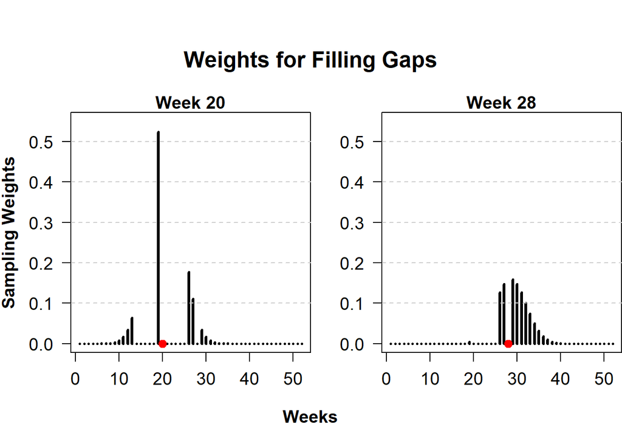

```r
bnWt <- stats::dbinom(0L:51L, 51L, 0.5)
idWt <- \(t) ((0L:51L + 26L - t) %% 52L) + 1L
getWts <- \(t) (bnWt[idWt(t)] * nonGap) |> (\(x) x / sum(x))()
p <- lapply(gapIdx, getWts) |> setNames(paste("Week", gapIdx))


gPar <- list(
  fig = c(0, .5, 0, 1),
  mar = c(0, 4, 1.2, 0),
  oma = c(2,0,2,0),
  pty = "s",
  las = 1,
  cex.axis = 1.2,
  cex.lab = 1.2,
  font.lab = 2,
  new = FALSE
)

plotPar <- list(
  x = p[["Week 20"]],
  type = "h",
  xlab = "",
  ylab = "Sampling Weights",
  main = "Week 20",
  lwd = 3,
  ylim = c(0, 0.55)
)


addLnPnt <- \(x) {
  points(x, 0, cex = 1.2, pch = 19, col = "red")
  abline(h = c(1:5) / 10, lty = 2, col = "gray80")
}

do.call(par, gPar)
do.call(plot, plotPar)
addLnPnt(20)

gPar[c("fig", "new")] = list(c(.5, 1, 0, 1), TRUE)
plotPar[c("x", "main", "ylab")] = list(p[["Week 28"]], "Week 28", "")
do.call(par, gPar)
do.call(plot, plotPar)
addLnPnt(28)

mtext("Weights for Filling Gaps", 3, -2, TRUE, cex = 1.5, font = 2)
mtext("Weeks", 1, 0, TRUE, cex = 1.2, font = 2)
```

```r
do.call(par, oldPar)
```

```r
len <- length(gapIdx)
wk <- seq_len(len) |> setNames(names(p))

btstrp <- \() vapply(wk, \(x) sample(nonGapVals, 1), 0L)
bnm <- \(n = 1) vapply(wk, \(x) mean(sample(train, n, FALSE, p[[x]])), .0)
list2df <- \(x) do.call(rbind, x) |> as.data.frame()

nSim <- seq_len(1e4)
dfs <- list()
dfs[["Bootstrap"]] <- lapply(nSim, \(x) btstrp()) |> list2df()
dfs[["Binom"]]     <- lapply(nSim, \(x) bnm(1L))  |> list2df()
dfs[["BinomMu3"]]  <- lapply(nSim, \(x) bnm(3L))  |> list2df()
dfs[["BinomMu6"]]  <- lapply(nSim, \(x) bnm(6L))  |> list2df()
dfs[["BinomMu9"]]  <- lapply(nSim, \(x) bnm(9L))  |> list2df()

out <- numeric(len) |> setNames(names(p))
reportMeanCVUnit <- \(x) sprintf("%5.2f (%3.1f)", mean(x), sd(x) / mean(x))
reportMeanSdUnit <- \(x) sprintf("%5.2f (%3.1f)", mean(x), sd(x))
reportMeanCV <- function(df) {
  out <- lapply(df, reportMeanCVUnit) |> cbind()
  N <- ((apply(df, 1, sum)) + 18) |> reportMeanSdUnit()
  rbind(out, N)
}

for (i in seq_len(len)) out[i] <- sum(train * p[[i]])
WtMean <- c(out, 18 + sum(out)) |> sprintf(fmt = "%5.2f", ... = _)
MeanCV <- lapply(dfs, reportMeanCV) |> as.data.frame()

cbind(WtMean, MeanCV)
```

|  | WtMean | Bootstrap | Binom | BinomMu3 | BinomMu6 | BinomMu9 |
| --- | --- | --- | --- | --- | --- | --- |
| Week 14 | 0.14 | 0.51 (1.5) | 0.14 (2.5) | 0.15 (1.3) | 0.17 (0.6) | 0.21 (0.4) |
| Week 15 | 0.21 | 0.50 (1.5) | 0.20 (2.0) | 0.21 (0.9) | 0.20 (0.5) | 0.24 (0.4) |
| Week 16 | 0.33 | 0.51 (1.5) | 0.33 (1.5) | 0.28 (0.7) | 0.24 (0.6) | 0.29 (0.4) |
| Week 17 | 0.47 | 0.51 (1.5) | 0.48 (1.1) | 0.37 (0.6) | 0.32 (0.5) | 0.33 (0.2) |
| Week 18 | 0.64 | 0.51 (1.5) | 0.63 (0.9) | 0.49 (0.6) | 0.42 (0.4) | 0.34 (0.1) |
| Week 20 | 0.88 | 0.52 (1.5) | 0.87 (0.8) | 0.76 (0.4) | 0.50 (0.2) | 0.36 (0.2) |
| Week 21 | 0.91 | 0.52 (1.5) | 0.91 (0.8) | 0.80 (0.4) | 0.52 (0.2) | 0.39 (0.3) |
| Week 22 | 0.88 | 0.52 (1.5) | 0.87 (1.0) | 0.78 (0.4) | 0.55 (0.2) | 0.46 (0.3) |
| Week 23 | 0.81 | 0.52 (1.5) | 0.82 (1.1) | 0.72 (0.5) | 0.57 (0.3) | 0.55 (0.2) |
| Week 24 | 0.72 | 0.49 (1.5) | 0.72 (1.3) | 0.65 (0.5) | 0.57 (0.3) | 0.61 (0.2) |
| Week 25 | 0.64 | 0.50 (1.5) | 0.65 (1.4) | 0.60 (0.6) | 0.56 (0.3) | 0.64 (0.2) |
| Week 28 | 0.52 | 0.50 (1.5) | 0.53 (1.7) | 0.53 (0.8) | 0.58 (0.4) | 0.68 (0.2) |
| Week 41 | 0.63 | 0.51 (1.5) | 0.62 (1.3) | 0.65 (0.6) | 0.72 (0.3) | 0.77 (0.2) |
| Week 42 | 0.58 | 0.50 (1.5) | 0.58 (1.3) | 0.60 (0.7) | 0.65 (0.4) | 0.70 (0.2) |
| Week 43 | 0.56 | 0.50 (1.5) | 0.56 (1.4) | 0.58 (0.7) | 0.59 (0.4) | 0.61 (0.2) |
| Week 44 | 0.56 | 0.52 (1.5) | 0.55 (1.4) | 0.55 (0.7) | 0.54 (0.4) | 0.54 (0.2) |
| Week 45 | 0.55 | 0.52 (1.5) | 0.54 (1.4) | 0.54 (0.7) | 0.52 (0.4) | 0.49 (0.3) |
| N | 28.01 | 26.68 (3.2) | 28.01 (3.0) | 27.26 (1.4) | 26.20 (0.7) | 26.22 (0.5) |

```r
lapply(dfs, \(x) { round(rowSums(x) + 18) |>  quantile(c(.025, .5, .975))}) |>
  do.call(rbind, args = _) |>
  as.data.frame()
```

|  | 2.5% | 50% | 97.5% |
| --- | --- | --- | --- |
| Bootstrap | 21 | 27 | 33 |
| Binom | 22 | 28 | 34 |
| BinomMu3 | 25 | 27 | 30 |
| BinomMu6 | 25 | 26 | 28 |
| BinomMu9 | 25 | 26 | 27 |

On lines 8-9 (15-16 in source), the **‘isoweek’** and **‘year’** functions are used to create new columns in the **‘grips’**. The year 2019 appears to have logs in its 1st week although recruitment started on the 25th.

I think we should use **‘isoyear’** function instead of the **‘year’** function.

## Seasonality out of sync?

The **‘onesimulationwt’** function is defined on line 211 in **‘source’**. Loop starts with **‘probvector’** aligned for week 1 (line 13) and increments (line 17) until enough subjects are included. I think it should start with the first **week index** of the period we make the prediction for. This is the 25th week for **‘grips2ndy’** (prediction dataset).

## Gap weeks

The **`fillgaps`** function is defined on line 501 in **`source`**. **`fillgaps`** 2nd argument (**`variable`**) is the variable column index to be used to check for gaps weeks. We should definitely change it to varname instead of index. On line 15 (515 in source), the function is called with **`variable = 4`**. This is the index of the **Sum_Meets_Crit** `(weekly summation of criteria met)` column. Was this the intended column?

Also, **`fillgaps`** replaces the whole row of gap weeks with non-gap weeks. That is, even the **`week`** and **`year`** columns are replaced. Finally, should we use weights for more probable sampling from adjacent weeks?

## Account for holidays

The **onesimulationwtd** function is defined on line 648 in **source**. It is implemented using **‘dataset = grips1sty’** as 1st argument on line 717 in source. The **`grips1sty$isholiday`** variable is the sum of holidays within each calendar week (each row). On line 6 (684 in source), the boolean vector **‘a’** is created as **`dataset$isholiday == 0`**. That is, for weeks with no holidays it equals **‘1 (TRUE)’** and **‘0 (FALSE)’** for weeks that had at least one day out of 5 business days as a holiday. On line 7, the binomial weights vector is created based on current week index. On line 8, the weights are adjusted using the **‘a’** boolean vector. **Questions/issues**:

- We assign **0** (zero) weight to weeks with just one holiday.
- We do not take into account whether the current week index for target dataset (grips2ndy) is a week with a holiday or not.

## Code efficiency

Here, I will use the **‘onesimulationwt’** function, presented also in **Comment 2**, as a representative example. Please, note that this function is called once for every simulation.

1. Line 5: **‘wt1’** is a vector is calculated anew for every simulation.
2. Line 6: **‘wtatt’** function is defined anew every time (inside the main function).
3. Line 11: **’scalar1** function the same as above.
4. Line 14: We just need to sample 1 value from the **Sum_Enrolled** column. It is inefficient to sample/query the whole row of a dataframe.
5. Line 14: **nrow(dataset))** is calculated [#Simulations * #Loops] times although is a constant.
6. Line 15: Using **‘rbind’** to add a row to a data frame is inefficient.
7. Line 16: **‘probvector’** is recalculated for every row of the simulation data frame.

We can calculate weights (replace **wt1**) and define **‘wtatt’** function in the global environment once as follows

```r
binomWt <- dbinom(0L:51L, 51L, 0.5) |> (\(x)  x / sum(x))()
indxWt <- function(t) ((0L:51L + 26L - t) %% 52L) + 1L
probVec <- function(t) binomWt[indxWt(t)]
```